# Johns Hopkins COVID Visualizations and Analysis

3/6/2023

This assignment will examine COVID cases around the world, using data from Johns Hopkins. “https://raw.githubusercontent.com/CSSEGISandData/COVID-19/master/csse_covid_19_data/csse_covid_19_time_series/”. For this report, I will be looking at three things. First, whether or not there any noticable differences between the per capita cases and deaths for California and Wyoming. Second, plotting the cases and deaths in Japan, to see any trend, and lastly, if we can accurately predict the number of cases in Japan from 2020-2023.

# 1. Setup

### 1.1. Load Packages

Here, we load any required packages. In this report, we are using the tidyverse and lubridate packages.

```r
library(tidyverse)
library(lubridate)
```

### 1.2. Load Data

Once the packages are loaded, we retrieve the dataset we are using for our visualizations and model.

```r
url_in <- "https://raw.githubusercontent.com/CSSEGISandData/COVID-19/master/csse_covid_19_data/csse_covid_19_time_series/"

files <- c("time_series_covid19_confirmed_US.csv",
           "time_series_covid19_confirmed_global.csv",
           "time_series_covid19_deaths_US.csv",
           "time_series_covid19_deaths_global.csv")

urls <- str_c(url_in, files)

us_cases <- read_csv(urls[1])
global_cases <- read_csv(urls[2])
us_deaths <- read_csv(urls[3])
global_deaths <- read_csv(urls[4])
```

### 1.3. Clean Data - Global

At the moment, our data has a column for each date in the data set. We will first pivot the global cases and deaths to give each date and “Country/Region” it’s own row. We will then join global_cases, and global_deaths, to create a single global table with cases and deaths in the same dataframe.

```r
global_cases <- global_cases %>%
  pivot_longer(cols = -c("Province/State",
                         "Country/Region", Lat, Long),
               names_to = "date",
               values_to = "cases") %>%
  select(-c(Lat,Long))
global_cases
```

```
## # A tibble: 328,882 × 4
##    `Province/State` `Country/Region` date    cases
##    <chr>            <chr>            <chr>   <dbl>
##  1 <NA>             Afghanistan      1/22/20     0
##  2 <NA>             Afghanistan      1/23/20     0
##  3 <NA>             Afghanistan      1/24/20     0
##  4 <NA>             Afghanistan      1/25/20     0
##  5 <NA>             Afghanistan      1/26/20     0
##  6 <NA>             Afghanistan      1/27/20     0
##  7 <NA>             Afghanistan      1/28/20     0
##  8 <NA>             Afghanistan      1/29/20     0
##  9 <NA>             Afghanistan      1/30/20     0
## 10 <NA>             Afghanistan      1/31/20     0
## # … with 328,872 more rows
```

```r
global_deaths <- global_deaths %>%
  pivot_longer(cols = -c("Province/State",
                         "Country/Region", Lat, Long),
               names_to = "date",
               values_to = "deaths") %>%
  select(-c(Lat,Long))
global_deaths
```

```
## # A tibble: 328,882 × 4
##    `Province/State` `Country/Region` date    deaths
##    <chr>            <chr>            <chr>    <dbl>
##  1 <NA>             Afghanistan      1/22/20      0
##  2 <NA>             Afghanistan      1/23/20      0
##  3 <NA>             Afghanistan      1/24/20      0
##  4 <NA>             Afghanistan      1/25/20      0
##  5 <NA>             Afghanistan      1/26/20      0
##  6 <NA>             Afghanistan      1/27/20      0
##  7 <NA>             Afghanistan      1/28/20      0
##  8 <NA>             Afghanistan      1/29/20      0
##  9 <NA>             Afghanistan      1/30/20      0
## 10 <NA>             Afghanistan      1/31/20      0
## # … with 328,872 more rows
```

```r
global <- global_cases %>%
  full_join(global_deaths) %>%
  rename(Country_Region = "Country/Region",
         Province_Sate = "Province/State") %>%
  mutate(date = mdy(date))
global
```

```
## # A tibble: 328,882 × 5
##    Province_Sate Country_Region date       cases deaths
##    <chr>         <chr>          <date>     <dbl>  <dbl>
##  1 <NA>          Afghanistan    2020-01-22     0      0
##  2 <NA>          Afghanistan    2020-01-23     0      0
##  3 <NA>          Afghanistan    2020-01-24     0      0
##  4 <NA>          Afghanistan    2020-01-25     0      0
##  5 <NA>          Afghanistan    2020-01-26     0      0
##  6 <NA>          Afghanistan    2020-01-27     0      0
##  7 <NA>          Afghanistan    2020-01-28     0      0
##  8 <NA>          Afghanistan    2020-01-29     0      0
##  9 <NA>          Afghanistan    2020-01-30     0      0
## 10 <NA>          Afghanistan    2020-01-31     0      0
## # … with 328,872 more rows
```

Now we have a single global table with both cases and deaths.

### 1.4. Clean Data - U.S.

Here we will utilize a similar process as to what we did for the global cases, to create a single table with cases and deaths in the U.S. For the combined data, I am looking to have states, cases, and deaths, as columns, and the dates as my rows.

```r
us_cases <- us_cases %>%
  pivot_longer(cols = -c(Province_State,
                         Country_Region,
                         iso2, iso3,
                         Admin2, Combined_Key,
                         Lat, Long_,
                         UID, code3,
                         FIPS),
               names_to = "date",
               values_to = "cases") %>%
  select(-c(iso2, iso3,
            Admin2, Combined_Key,
            Lat, Long_,
            UID, code3, FIPS))

us_cases <- us_cases  %>%
  group_by(Province_State, Country_Region, date) %>%
  summarize(total_cases = sum(cases))
us_cases
```

```
## # A tibble: 66,004 × 4
## # Groups:   Province_State, Country_Region [58]
##    Province_State Country_Region date    total_cases
##    <chr>          <chr>          <chr>         <dbl>
##  1 Alabama        US             1/1/21       365747
##  2 Alabama        US             1/1/22       896614
##  3 Alabama        US             1/1/23      1568934
##  4 Alabama        US             1/10/21      401900
##  5 Alabama        US             1/10/22      984882
##  6 Alabama        US             1/10/23     1587224
##  7 Alabama        US             1/11/21      404000
##  8 Alabama        US             1/11/22      993418
##  9 Alabama        US             1/11/23     1596149
## 10 Alabama        US             1/12/21      407848
## # … with 65,994 more rows
```

```r
us_deaths <- us_deaths %>%
  pivot_longer(cols = -c(Province_State,
                         Country_Region,
                         iso2, iso3,
                         Admin2, Combined_Key,
                         Lat, Long_,
                         UID, code3,
                         FIPS, Population),
               names_to = "date",
               values_to = "deaths") %>%
  select(-c(iso2, iso3,
            Admin2, Combined_Key,
            Lat, Long_,
            UID, code3, FIPS))%>%
  ungroup()

us_deaths <- us_deaths %>%
  group_by(Province_State, Country_Region, date) %>%
  summarize(total_deaths = sum(deaths),
           total_population = sum(Population))%>%
  ungroup()
us_deaths
```

```
## # A tibble: 66,004 × 5
##    Province_State Country_Region date    total_deaths total_population
##    <chr>          <chr>          <chr>          <dbl>            <dbl>
##  1 Alabama        US             1/1/21          4872          4903185
##  2 Alabama        US             1/1/22         16455          4903185
##  3 Alabama        US             1/1/23         20737          4903185
##  4 Alabama        US             1/10/21         5334          4903185
##  5 Alabama        US             1/10/22        16624          4903185
##  6 Alabama        US             1/10/23        20776          4903185
##  7 Alabama        US             1/11/21         5347          4903185
##  8 Alabama        US             1/11/22        16630          4903185
##  9 Alabama        US             1/11/23        20820          4903185
## 10 Alabama        US             1/12/21         5573          4903185
## # … with 65,994 more rows
```

From here we will join the U.S. cases data and deaths data to create one table.

```r
us <- us_cases %>%
  full_join(us_deaths) %>%
  mutate(date = mdy(date))%>%
  ungroup()
us
```

```
## # A tibble: 66,004 × 6
##    Province_State Country_Region date       total_cases total_deaths total_pop…¹
##    <chr>          <chr>          <date>           <dbl>        <dbl>       <dbl>
##  1 Alabama        US             2021-01-01      365747         4872     4903185
##  2 Alabama        US             2022-01-01      896614        16455     4903185
##  3 Alabama        US             2023-01-01     1568934        20737     4903185
##  4 Alabama        US             2021-01-10      401900         5334     4903185
##  5 Alabama        US             2022-01-10      984882        16624     4903185
##  6 Alabama        US             2023-01-10     1587224        20776     4903185
##  7 Alabama        US             2021-01-11      404000         5347     4903185
##  8 Alabama        US             2022-01-11      993418        16630     4903185
##  9 Alabama        US             2023-01-11     1596149        20820     4903185
## 10 Alabama        US             2021-01-12      407848         5573     4903185
## # … with 65,994 more rows, and abbreviated variable name ¹total_population
```

```r
ca <- filter(us, Province_State == "California")%>%
  mutate(cases_per_capita = total_cases/total_population,
         deaths_per_capita = total_deaths/total_population)
ca
```

```
## # A tibble: 1,138 × 8
##    Province_State Country_R…¹ date       total…² total…³ total…⁴ cases…⁵ death…⁶
##    <chr>          <chr>       <date>       <dbl>   <dbl>   <dbl>   <dbl>   <dbl>
##  1 California     US          2021-01-01  2.43e6   26258  3.95e7  0.0616 6.65e-4
##  2 California     US          2022-01-01  5.52e6   76480  3.95e7  0.140  1.94e-3
##  3 California     US          2023-01-01  1.18e7   98637  3.95e7  0.300  2.50e-3
##  4 California     US          2021-01-10  2.82e6   29986  3.95e7  0.0713 7.59e-4
##  5 California     US          2022-01-10  6.39e6   77152  3.95e7  0.162  1.95e-3
##  6 California     US          2023-01-10  1.19e7   99027  3.95e7  0.302  2.51e-3
##  7 California     US          2021-01-11  2.85e6   30204  3.95e7  0.0722 7.64e-4
##  8 California     US          2022-01-11  6.54e6   77175  3.95e7  0.166  1.95e-3
##  9 California     US          2023-01-11  1.19e7   99066  3.95e7  0.302  2.51e-3
## 10 California     US          2021-01-12  2.89e6   30798  3.95e7  0.0732 7.79e-4
## # … with 1,128 more rows, and abbreviated variable names ¹Country_Region,
## #   ²total_cases, ³total_deaths, ⁴total_population, ⁵cases_per_capita,
## #   ⁶deaths_per_capita
```

```r
wy <- filter(us, Province_State == "Wyoming")%>%
  mutate(cases_per_capita = total_cases/total_population,
         deaths_per_capita = total_deaths/total_population)
wy
```

```
## # A tibble: 1,138 × 8
##    Province_State Country_R…¹ date       total…² total…³ total…⁴ cases…⁵ death…⁶
##    <chr>          <chr>       <date>       <dbl>   <dbl>   <dbl>   <dbl>   <dbl>
##  1 Wyoming        US          2021-01-01   44409     438  578759  0.0767 7.57e-4
##  2 Wyoming        US          2022-01-01  115638    1526  578759  0.200  2.64e-3
##  3 Wyoming        US          2023-01-01  182847    1958  578759  0.316  3.38e-3
##  4 Wyoming        US          2021-01-10   46832     489  578759  0.0809 8.45e-4
##  5 Wyoming        US          2022-01-10  121519    1572  578759  0.210  2.72e-3
##  6 Wyoming        US          2023-01-10  183385    1967  578759  0.317  3.40e-3
##  7 Wyoming        US          2021-01-11   47395     489  578759  0.0819 8.45e-4
##  8 Wyoming        US          2022-01-11  122754    1588  578759  0.212  2.74e-3
##  9 Wyoming        US          2023-01-11  183385    1967  578759  0.317  3.40e-3
## 10 Wyoming        US          2021-01-12   48072     522  578759  0.0831 9.02e-4
## # … with 1,128 more rows, and abbreviated variable names ¹Country_Region,
## #   ²total_cases, ³total_deaths, ⁴total_population, ⁵cases_per_capita,
## #   ⁶deaths_per_capita
```

```r
total_us <- us%>%
  select(-c(Province_State))%>%
  group_by(Country_Region, date)%>%
  summarize(total_cases = sum(total_cases),
            total_deaths = sum(total_deaths),
            total_population = sum(total_population))%>%
  ungroup()
total_us
```

```
## # A tibble: 1,138 × 5
##    Country_Region date       total_cases total_deaths total_population
##    <chr>          <date>           <dbl>        <dbl>            <dbl>
##  1 US             2020-01-22           1            1        332875137
##  2 US             2020-01-23           1            1        332875137
##  3 US             2020-01-24           2            1        332875137
##  4 US             2020-01-25           2            1        332875137
##  5 US             2020-01-26           5            1        332875137
##  6 US             2020-01-27           5            1        332875137
##  7 US             2020-01-28           5            1        332875137
##  8 US             2020-01-29           6            1        332875137
##  9 US             2020-01-30           6            1        332875137
## 10 US             2020-01-31           8            1        332875137
## # … with 1,128 more rows
```

# 2. Visualizations

For my first visualization, I will look at cases in California, the most populous state, and Wyoming, the least populous state. To see if the case and death numbers look any different. For both of these, I will look at per capita data.

```r
ca <- filter(us, Province_State == "California")%>%
  mutate(cases_per_capita = total_cases/total_population*1000,
         deaths_per_capita = total_deaths/total_population*1000)
ca
```

```
## # A tibble: 1,138 × 8
##    Province_State Country_R…¹ date       total…² total…³ total…⁴ cases…⁵ death…⁶
##    <chr>          <chr>       <date>       <dbl>   <dbl>   <dbl>   <dbl>   <dbl>
##  1 California     US          2021-01-01  2.43e6   26258  3.95e7    61.6   0.665
##  2 California     US          2022-01-01  5.52e6   76480  3.95e7   140.    1.94
##  3 California     US          2023-01-01  1.18e7   98637  3.95e7   300.    2.50
##  4 California     US          2021-01-10  2.82e6   29986  3.95e7    71.3   0.759
##  5 California     US          2022-01-10  6.39e6   77152  3.95e7   162.    1.95
##  6 California     US          2023-01-10  1.19e7   99027  3.95e7   302.    2.51
##  7 California     US          2021-01-11  2.85e6   30204  3.95e7    72.2   0.764
##  8 California     US          2022-01-11  6.54e6   77175  3.95e7   166.    1.95
##  9 California     US          2023-01-11  1.19e7   99066  3.95e7   302.    2.51
## 10 California     US          2021-01-12  2.89e6   30798  3.95e7    73.2   0.779
## # … with 1,128 more rows, and abbreviated variable names ¹Country_Region,
## #   ²total_cases, ³total_deaths, ⁴total_population, ⁵cases_per_capita,
## #   ⁶deaths_per_capita
```

```r
wy <- filter(us, Province_State == "Wyoming")%>%
  mutate(cases_per_capita = total_cases/total_population*1000,
         deaths_per_capita = total_deaths/total_population*1000)
wy
```

```
## # A tibble: 1,138 × 8
##    Province_State Country_R…¹ date       total…² total…³ total…⁴ cases…⁵ death…⁶
##    <chr>          <chr>       <date>       <dbl>   <dbl>   <dbl>   <dbl>   <dbl>
##  1 Wyoming        US          2021-01-01   44409     438  578759    76.7   0.757
##  2 Wyoming        US          2022-01-01  115638    1526  578759   200.    2.64
##  3 Wyoming        US          2023-01-01  182847    1958  578759   316.    3.38
##  4 Wyoming        US          2021-01-10   46832     489  578759    80.9   0.845
##  5 Wyoming        US          2022-01-10  121519    1572  578759   210.    2.72
##  6 Wyoming        US          2023-01-10  183385    1967  578759   317.    3.40
##  7 Wyoming        US          2021-01-11   47395     489  578759    81.9   0.845
##  8 Wyoming        US          2022-01-11  122754    1588  578759   212.    2.74
##  9 Wyoming        US          2023-01-11  183385    1967  578759   317.    3.40
## 10 Wyoming        US          2021-01-12   48072     522  578759    83.1   0.902
## # … with 1,128 more rows, and abbreviated variable names ¹Country_Region,
## #   ²total_cases, ³total_deaths, ⁴total_population, ⁵cases_per_capita,
## #   ⁶deaths_per_capita
```

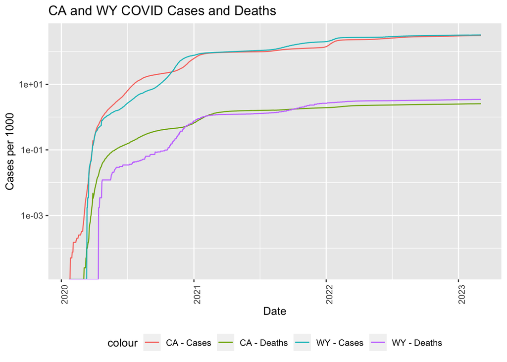

```r
ggplot() +
  geom_line(data = ca, aes(x = date, y = cases_per_capita, color = "CA - Cases" ))+
  geom_line(data = ca, aes(x = date, y = deaths_per_capita, color = "CA - Deaths" ))+
  geom_line(data = wy, aes(x = date, y = cases_per_capita, color = "WY - Cases" ))+
  geom_line(data = wy, aes(x = date, y = deaths_per_capita, color = "WY - Deaths" ))+

  theme(legend.position="bottom",
        axis.text.x = element_text(angle=90)) +
  labs(title = "CA and WY COVID Cases and Deaths", y="Cases per 1000", x="Date")+
  scale_y_continuous(trans='log10')
```

Based on the visualizations, it seems the Covid case and death numbers normalized for population are similar for California and Wyoming. The California observes cases and deaths earlier than Wyoming, which is expected. Next, we will look at Covid cases and deaths in Japan.

```r
japan <- (filter(global, Country_Region == "Japan"))
japan
```

```
## # A tibble: 1,138 × 5
##    Province_Sate Country_Region date       cases deaths
##    <chr>         <chr>          <date>     <dbl>  <dbl>
##  1 <NA>          Japan          2020-01-22     2      0
##  2 <NA>          Japan          2020-01-23     2      0
##  3 <NA>          Japan          2020-01-24     2      0
##  4 <NA>          Japan          2020-01-25     2      0
##  5 <NA>          Japan          2020-01-26     4      0
##  6 <NA>          Japan          2020-01-27     4      0
##  7 <NA>          Japan          2020-01-28     7      0
##  8 <NA>          Japan          2020-01-29     7      0
##  9 <NA>          Japan          2020-01-30    11      0
## 10 <NA>          Japan          2020-01-31    15      0
## # … with 1,128 more rows
```

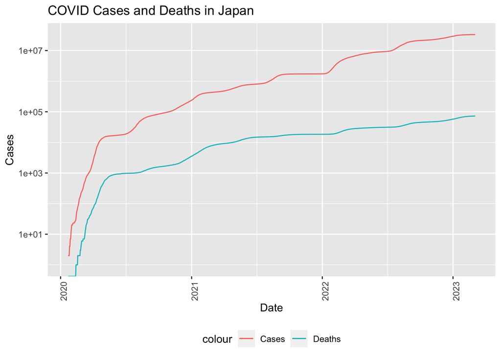

```r
japan %>%
  ggplot() +
  geom_line(data = japan, aes(x = date, y = cases, color = "Cases" ))+
  geom_line(data = japan, aes(x = date, y = deaths, color = "Deaths" ))+
  theme(legend.position="bottom",
        axis.text.x = element_text(angle=90)) +
  labs(title = "COVID Cases and Deaths in Japan", y="Cases", x="Date")+
  scale_y_continuous(trans='log10')
```

Based on the visualization of cases and deaths in Japan, it seems that the ratio between cases and deaths remains fairly constant in the early parts, and a lower number of deaths per cases over time.

# 3. Model

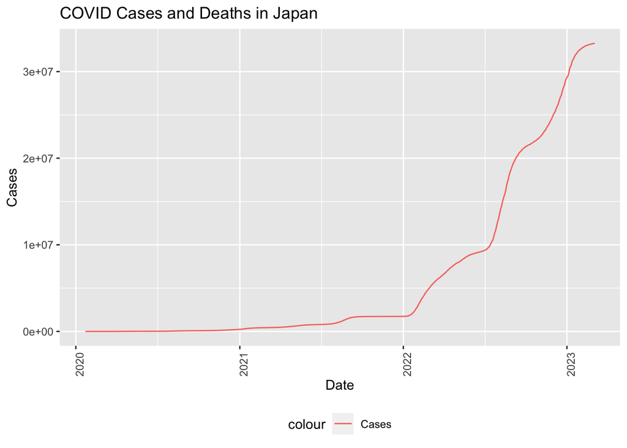

```r
japan %>%
  ggplot() +
  geom_line(data = japan, aes(x = date, y = cases, color = "Cases" ))+
  theme(legend.position="bottom",
        axis.text.x = element_text(angle=90))+
  labs(title = "COVID Cases and Deaths in Japan", y="Cases", x="Date")
```

Since the graph for Covid cases in Japan appears to have an exponential relationship. I will see how an exponential model fits. To do this, I will apply a linear model to the log of cases.

```r
model <- lm(log(cases) ~ date, data = japan)
summary(model)
```

```
##
## Call:
## lm(formula = log(cases) ~ date, data = japan)
##
## Residuals:
##     Min      1Q  Median      3Q     Max
## -7.5407 -0.2792  0.2196  0.7527  1.2551
##
## Coefficients:
##               Estimate Std. Error t value Pr(>|t|)
## (Intercept) -1.584e+02  2.032e+00  -77.93   <2e-16 ***
## date         9.112e-03  1.078e-04   84.53   <2e-16 ***
## ---
## Signif. codes:  0 '***' 0.001 '**' 0.01 '*' 0.05 '.' 0.1 ' ' 1
##
## Residual standard error: 1.195 on 1136 degrees of freedom
## Multiple R-squared:  0.8628, Adjusted R-squared:  0.8627
## F-statistic:  7145 on 1 and 1136 DF,  p-value: < 2.2e-16
```

```r
japan_pred <- japan %>% mutate(pred = exp(predict(model)))
japan_pred
```

```
## # A tibble: 1,138 × 6
##    Province_Sate Country_Region date       cases deaths  pred
##    <chr>         <chr>          <date>     <dbl>  <dbl> <dbl>
##  1 <NA>          Japan          2020-01-22     2      0 3665.
##  2 <NA>          Japan          2020-01-23     2      0 3698.
##  3 <NA>          Japan          2020-01-24     2      0 3732.
##  4 <NA>          Japan          2020-01-25     2      0 3766.
##  5 <NA>          Japan          2020-01-26     4      0 3801.
##  6 <NA>          Japan          2020-01-27     4      0 3836.
##  7 <NA>          Japan          2020-01-28     7      0 3871.
##  8 <NA>          Japan          2020-01-29     7      0 3906.
##  9 <NA>          Japan          2020-01-30    11      0 3942.
## 10 <NA>          Japan          2020-01-31    15      0 3978.
## # … with 1,128 more rows
```

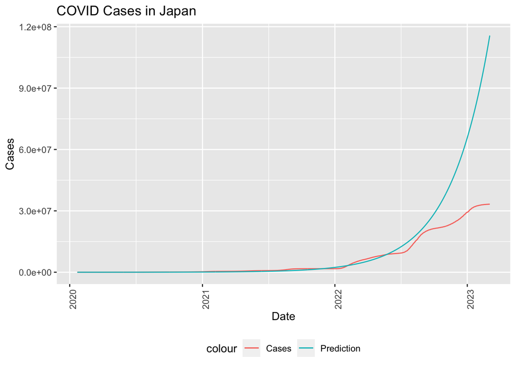

```r
japan_pred %>%
  ggplot() +
  geom_line(data = japan_pred, aes(x = date, y = cases, color = "Cases" ))+
  geom_line(data = japan_pred, aes(x = date, y = pred, color = "Prediction"))+
  theme(legend.position="bottom",
        axis.text.x = element_text(angle=90))+
  labs(title = "COVID Cases in Japan", y="Cases", x="Date")
```

Although the model implied a fairly strong exponential relationship, based on this last visualization, it seems the model would becomes weaker over time. The model seems to accurately track total cases until the middle of 2022 where the model and actual values diverge. This could be explained by a number of different factors, including vaccination rates, cultural acceptance of masking, etc.

# 4. Bias

As with any sort of data analysis and visualization, we need to identify any biases in our work. One source, is my familiarity with all of these regions examined in the report. I had a pretty good idea what the shape of these graphs looked like prior to graphing them. I was intilly a little surprised that the per capita cases and deaths data for California and Wyoming were so close, but after thinking about the data some more, I realized that it made sense. For the Japanese data, I knew that the graph would look a little different than the data from the U.S. given a number of factors, one of them being their cultural acceptance of masking. Other biases may include biases in the reporting. There may have been many incindents of Covid that were not tested, and therefore not counted as a case.